# Project 3 Vocab Building

Zeed Jarrah (zjarrah2)

Derek Chapman (derek4)

```r
library(glmnet)
library(tm)
library(text2vec)

set_cache = T
```

First we calculate the length of each review. We do not use a stop word list of any kind and include all 120,000 unique words (and some of them certainly are unique!)

```r
set.seed(0721)
data = read.table("alldata.tsv", stringsAsFactors = FALSE,
                   header = TRUE)
reviews_words = itoken(data$review,
               preprocessor = tolower,
               tokenizer = word_tokenizer)
full_vocab = create_vocabulary(reviews_words)
dtm_full_vocab  = create_dtm(reviews_words, vocab_vectorizer(full_vocab))

review_length = rowSums(dtm_full_vocab)
```

We can see that there is a wide range of review lengths.

```r
range(review_length)
```

```
## [1]    6 2493
```

Upon further inspection the longest reviews are definitely outliers and create a distribution with a very long, thin tail. If we ignore any review that is greater than 700 words we get a much nicer distribution that looks like a mix of a normal and a f-distribution.

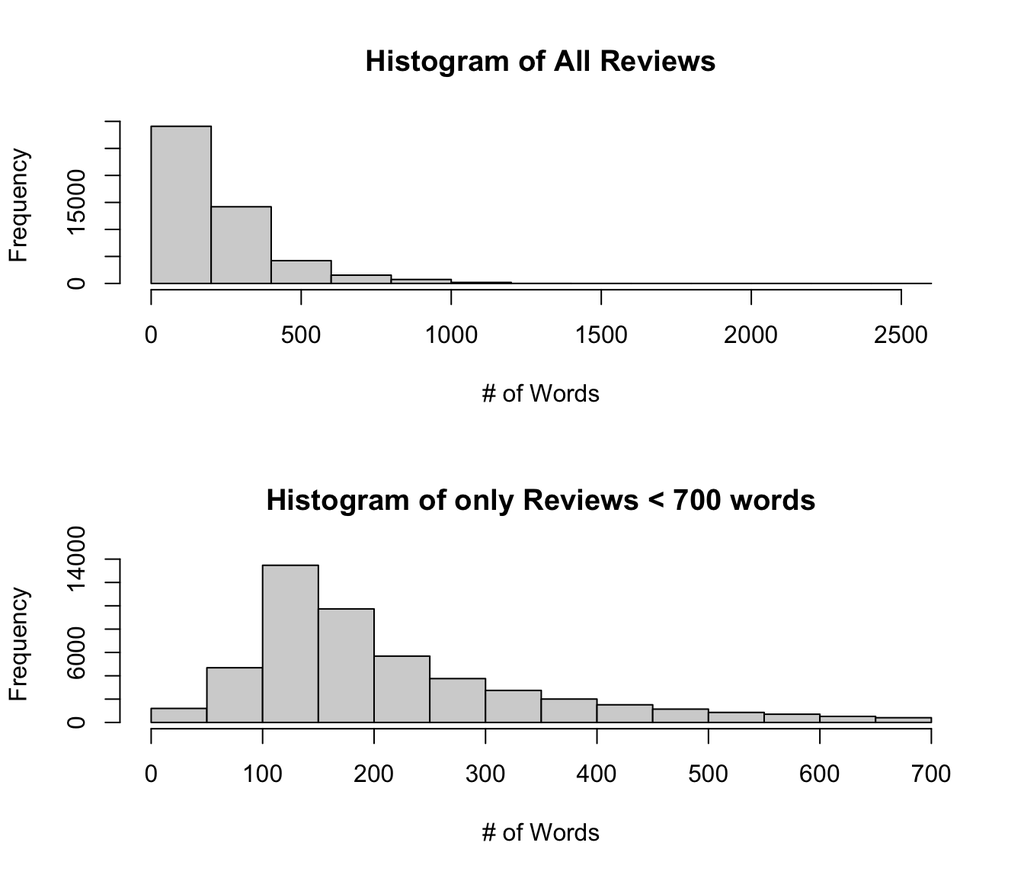

```r
par(mfrow = c(2,1))

hist(review_length,
     xlab = "# of Words",
     main = "Histogram of All Reviews")
hist(review_length[review_length < 700],
     xlab = "# of Words",
     main = "Histogram of only Reviews < 700 words")
```

We choose 700 words since it covers about 2 standard deviations worth of the data and cuts off only the outlier reviews. The reviews that are cut off are the most wordy and tended to skew our results and make our final vocab list much less interpretable and coherent.

```r
sum(review_length > 700) / length(review_length)
```

```
## [1] 0.031
```

```r
round(sum(review_length[review_length > 700]) / sum(review_length), 3)
```

```
## [1] 0.114
```

We see that while long reviews make up about 3% of the total number of reviews they take up over a tenth of the entire amount of words for all reviews.  
Next we grab all the indices of reviews that are less than 700 words and subset our data.

```r
short_idx = which(review_length < 700)

train_short = data[short_idx, ]
train_short$review = gsub('<.*?>', ' ', train_short$review)
```

```r
stop_words = c("i", "me", "my", "myself",
               "we", "our", "ours", "ourselves",
               "you", "your", "yours",
               "their", "they", "his", "her",
               "she", "he", "a", "an", "and",
               "is", "was", "are", "were",
               "him", "himself", "has", "have",
               "it", "its", "the", "us")
word_select = itoken(train_short$review,
                        preprocessor = tolower,
                        tokenizer = word_tokenizer)
short_vocab = create_vocabulary(word_select,
                              stopwords = stop_words,
                              ngram = c(1L,4L))
short_vocab = prune_vocabulary(short_vocab, term_count_min = 10,
                              doc_proportion_max = 0.5,
                              doc_proportion_min = 0.001)

dtm_word_short = create_dtm(word_select, vocab_vectorizer(short_vocab))
```

We then use The Lasso to do parameter selection, or in this case word selection. Next we use the lambda value that shrunk our word list down to less than 1000 words. to select the final word list from our model.

```r
short_mdl = glmnet(x = dtm_word_short, y = train_short$sentiment,
                  alpha = 1,
                  family='binomial')

benchmark_lamda = max(which(short_mdl$df < 1000))
myvocab = colnames(dtm_word_short)[which(short_mdl$beta[, benchmark_lamda] != 0)]
```

After this we hand tune the list somewhat. Although this list was chosen using lambda and cross-validation during the initial exploration we end up with some words that its useful to remove. Such as:

- Most of the digits like 1, 3, 7.5 since they are either non-specific or covered by other versions like 3_out_of_10
- Most of the ngrams in the format of “2_out_of_10” since this is covered by “2_out_of”. Its a safe assumption that the next work will be “10” in such a phrase.
- Some of the description style words/phrases such as “based_on_true_story”. This tells us very little about whether the person did/did not like the movie.
- There are also many words that are longer stems of other just as descriptive phrases. Such as “much_better_than”. This is an area where a more crafted stop words list may have been useful in selecting words but it also may be more effort
- Some words ended up with ridiculously small beta values due to the fact that they are not descriminitive words such as “lives”.
- There were also many words that were selected out by a further round of The Lasso since they could be setups for either positive or negative comments such as “lot_of_things”.

We also retain some words that The Lasso zeroed out such as “lot_of_fun”. Intuitively this should be an indication of a very positive review. Its possible that in this particular split of the data that it is not so helpful. We keep it in the vocab list in the hope that it helps in some of the splits.

- Keep some words that we know are strong indicators of negative reviews such as: “hated” and “clichés”
- Keep some words that are probably indicators of positive reviews such as: “genuine” and “witty”

```r
large_net <- read.table("alldata.tsv", stringsAsFactors = FALSE,
                   header = TRUE)

it_word_large = itoken(large_net$review,
                  preprocessor = tolower,
                  tokenizer = word_tokenizer)

large_vocab = create_vocabulary(it_word_large,
                              stopwords = stop_words,
                              ngram = c(1L,4L))
large_vocab = prune_vocabulary(large_vocab, term_count_min = 10,
                             doc_proportion_max = 0.5,
                             doc_proportion_min = 0.01)
dtm_word_select  = create_dtm(it_word_large, vocab_vectorizer(large_vocab))

#select words
tmpfit_cv = cv.glmnet(x = dtm_word_select,
                      y = large_net$sentiment,
                      alpha = 1,
                      family='binomial')

selected_fit = glmnet(x = dtm_word_select,
                      y = large_net$sentiment,
                      alpha = 0,
                      lambda = tmpfit_cv$lambda.1se,
                      family='binomial')

selected_words = colnames(dtm_word_select)[which(abs(selected_fit$beta) > .5)]
current_vocab = scan(file = "split_2/myvocab.txt", what = character())
for(word in selected_words){
  if(!(word %in% current_vocab)){
    print(paste(word, word %in% current_vocab))
  }
}
```

[output not shown]

Ultimately the hand-tuning of the vocab list was beneficial. It seems to have allowed more ‘probability mass’ to go to words with desciminitavie power rather than getting chipped away in small amounts by less helpful words.

Our final, programmaticly and hand-tuned, list is:

```r
myvocab = scan(file = "myvocab.txt", what = character())
length(myvocab)
```

```
## [1] 949
```

```r
myvocab
```

```
##   [1] "1_10"                  "1_out"                 "10_10"
##   [4] "10_out"                "2_10"                  "2_out"
##   [7] "3_10"                  "4_10"                  "7_10"
##  [10] "7_out"                 "8_10"                  "8_out"
##  [13] "80_s"                  "9_10"                  "about_as"
##  [16] "about_time"            "absolutely_no"         "absolutely_nothing"
##  [19] "absorbing"             "absurd"                "accent"
##  [22] "acting"                "actors"                "adds"
##  [25] "again"                 "again_again"           "ages"
##  [28] "all_in"                "alright"               "also"
##  [31] "although"              "always"                "amateurish"
##  [34] "amazing"               "animal"                "annoyed"
##  [37] "annoying"              "any"                   "anyone_interested"
##  [40] "anything"              "ape"                   "appalling"
##  [43] "apparently"            "appears"               "appreciate"
```

[output cut: 302 more lines]